Ride at Your Own Risk: Insights into Toronto’s Bicycle Theft Hotspots

Navigating Toronto’s streets with eyes wide open, this data-driven guide helps cyclists stay ahead of bicycle thieves.

Each year, countless bikes disappear from Toronto’s streets, leaving cyclists frustrated and vulnerable. Our analysis digs into patterns and insights across the city, highlighting where and when bicycles are most at risk. With data spanning over a decade, we reveal theft hotspots and provide tips to help keep your bike safe.

Yingke He, Ziheng Zhong  
November 18, 2024

Imagine locking up your bike on a bustling Toronto street, feeling reassured that a strong lock and some common sense will keep it safe. But what if certain seasons, specific bike types, or even certain neighborhoods increase your risk of theft far more than you realize? For many cyclists, bike theft has moved from a distant possibility to an everyday concern, with data revealing just how pervasive the risk can be in Toronto.

In this analysis, we dig into over a decade’s worth of data from the [Toronto Police Service](https://data.torontopolice.on.ca/datasets/TorontoPS::bicycle-thefts-open-data/about) (Toronto Police Service, 2024c) to answer key questions: When are bikes at the greatest risk? What makes a bike more likely to be targeted? And where are the theft hotspots cyclists should avoid? Each section of our article addresses a different angle of bike theft in Toronto, from seasonal and weekly theft patterns to variations by bicycle type and value, to pinpointing the city’s most high-risk locations.

Over the past decade, **32,489** bike thefts have been reported in Toronto, yet only **422** of these stolen bikes were successfully recovered. With these insights, we aim to empower cyclists with knowledge that can help them safeguard their bikes and inform Cycle Toronto and local authorities about the areas most in need of intervention. Read on as we trace theft trends over the years, reveal the high-risk locations, and provide practical advice to help protect your bike. But rather than just telling you the facts, let’s try something different—how about hearing it straight from the perspective of a **bike:**

Hi there! I’m a bicycle—just your regular two-wheeled friend. I’m here to take you places, let you feel the wind in your hair, and help you enjoy the streets of Toronto. Life might seem easy for me, but it’s not all smooth rides. In this city, there’s one big worry I face all the time: bike theft. And believe me, I’ve seen plenty of it.

Picture this: you lock me up on a busy Toronto street, thinking a strong lock and a little care will keep me safe. But the truth is, some seasons, certain types of bikes, and even specific areas make bikes like me much more likely to be stolen. Over the years, bike theft has gone from something that “might happen” to something we constantly have to worry about. But don’t worry—I’ve joined forces with some data experts to figure out what’s really happening.

When Are Bikes at the Greatest Risk?  
A Look at Seasonal and Weekly Patterns

[interactive chart not shown]

Note: Dragging the slider reveals daily bike theft patterns in Toronto, highlighting higher-risk days, with data covering 2014 to mid-2024.

It was Friday again, my least favorite day of the week. Don’t get me wrong, I love being ridden to the park or to the office, feeling the wind rushing past my handlebars. But Fridays? Fridays are dangerous. I’ve seen too many of my fellow bikes disappear on this day—snatched from racks, left lonely in crowded parking lots. Over **4,900** of us have gone missing on Fridays in Toronto. It’s not paranoia; it’s data.

You see, Fridays are chaotic. People rush to wrap up their week, juggling work and plans for the weekend. Some leave us in high-traffic zones, near pubs or downtown hotspots, forgetting how vulnerable we are. By Saturday and Sunday, the risk eases up a bit. Fewer commutes, fewer hurried stops. But Fridays? Fridays are a minefield.

If only they knew what the data shows. Advocacy groups like [Cycle Toronto](https://www.cycleto.ca/) (Cycle Toronto, 2021) have been raising awareness about these patterns. Perhaps one day, local authorities will patrol more on Fridays or run public awareness campaigns around hotspots. And for cyclists, knowing that Friday is the peak day for thefts might encourage them to lock us more securely or park in safer areas. I just hope these efforts take hold before more of us end up as another Friday statistic.

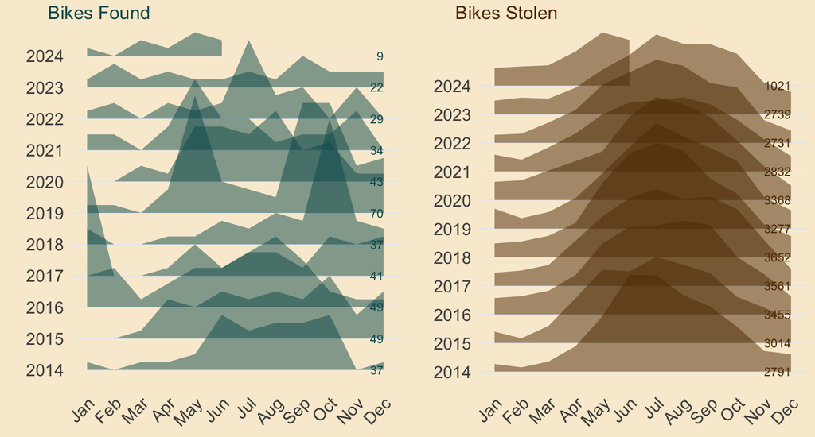

Bike theft and recovery patterns in Toronto from 2014 to 2024

Summer is supposed to be my favorite time of year. The warm weather, the long days, and the bustling streets filled with fellow bikes and riders. But as much as I love the attention, it also makes me nervous. Between May and August, thefts peak—this is when bikes like me are at the greatest risk. It’s not surprising, really. More people are out riding, whether it’s for fun or as their main way to get around, as the [City of Toronto](https://www.toronto.ca/wp-content/uploads/2021/04/8f76-2019-Cycling-Public-Option-Survey-City-of-Toronto-Cycling.pdf) (City of Toronto, 2019) has pointed out. Events like [Bike Month](https://www.bikemonth.ca/toronto) (Bike Month, 2024) in June bring even more of us out into the open, where thieves have more opportunities to strike. We become easy targets, exposed and vulnerable, even when we’re locked up securely.

And then there’s the sad reality of being found. While thousands of us go missing every year, the number of bikes recovered stays painfully low, no matter the season. Despite efforts like the [city-wide bike registry programs](https://www.tps.ca/services/bicycle-registration/) (Toronto Police Service, 2024a) and [police campaigns](https://www.tps.ca/crime-prevention/bicycle-safety-and-theft-prevention/) (Toronto Police Service, 2024b) to teach better locking techniques, the chances of being reunited with my rider are slim. Even with new [bike parking programs](https://www.toronto.ca/services-payments/streets-parking-transportation/cycling-in-toronto/bicycle-parking/) (City of Toronto, 2024) and secure lock stands, the efforts still feel small compared to how many of us disappear each year. I can’t help but wonder—what more can be done to keep me and my friends safe?

What Makes a Bike a Target?  
Analyzing Theft by Bicycle Type and Value

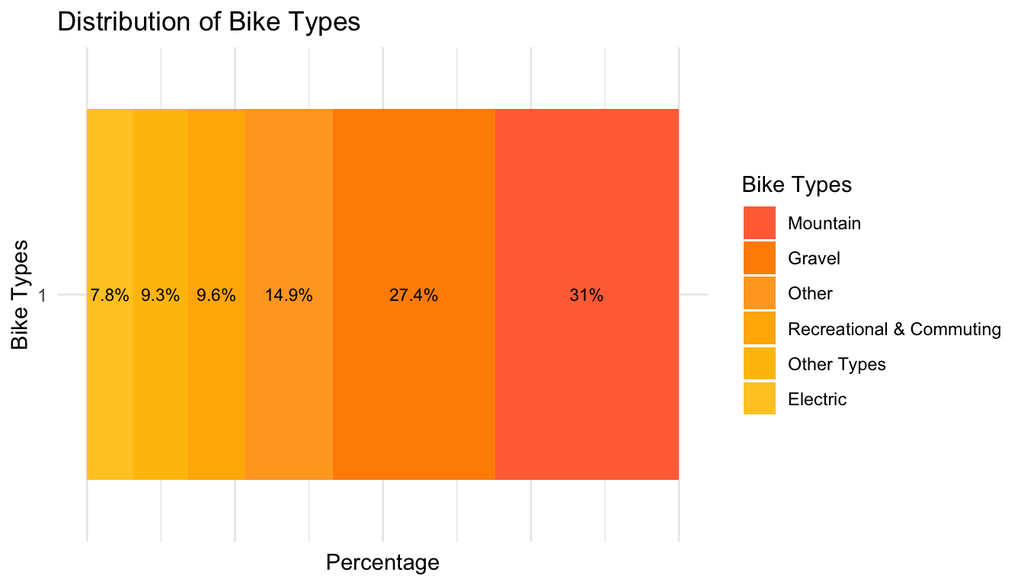

Electric bikes, though, seem to have it a bit easier. They only make up **7.8%** of stolen bikes. Maybe it’s because their owners tend to invest more in security—fancier locks, GPS trackers, or even parking us in safer spots. I guess it pays to be high-tech, but for the rest of us, being useful and everywhere means we’re always at risk.

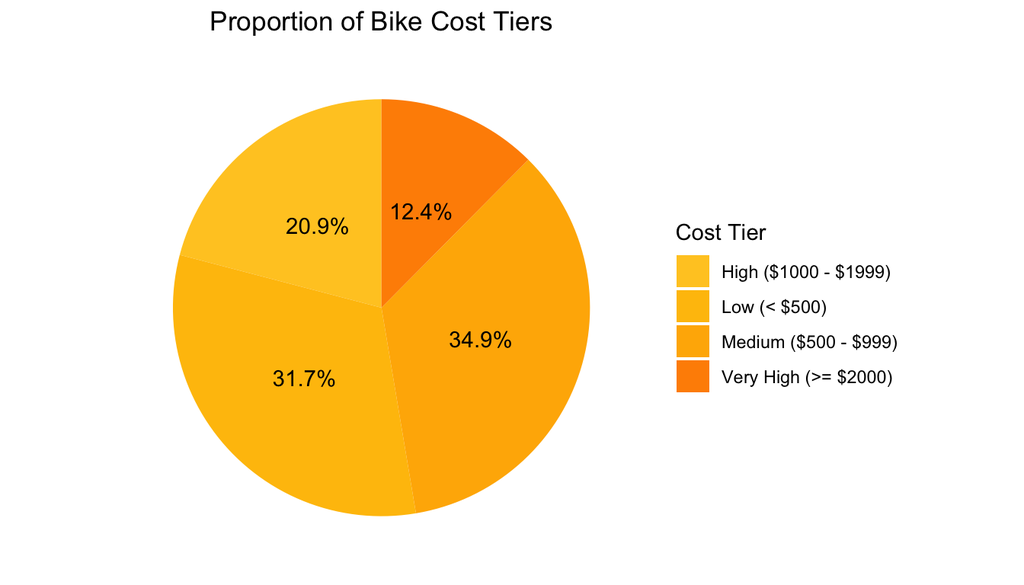

What does this mean for me and my friends? It’s simple: we all need protection, no matter our price tag. For lower-cost bikes like me, a strong U-lock or chain lock is a must. Parking in busy spots with security cameras or near bike racks helps too—anything to make thieves think twice. Even if I’m not worth a lot of money, taking these steps can make a big difference in keeping me safe.

Higher-value bikes, though, need even more care. If I were a high-end model, I’d hope for two locks—maybe a U-lock and a cable lock—and I’d beg you not to leave me outside overnight. Indoor storage is the gold standard. Oh, and registering me with Toronto’s bike registry or [Project 529](https://project529.com) (Toronto Police Service, 2024b; Project 529, 2024) would improve my chances of being found if something went wrong. Marking me with a unique ID or changing up where you park me can also keep thieves guessing. With the right precautions, we can stay out of trouble and keep riding the streets of Toronto together.

A Decade of Disappearing Bikes:  
Tracing Theft Trends Over Ten Years

[figure not shown]

Displays the count of various bicycle-related offences reported to the Toronto Police Service, highlighting categories such as stolen, found, and other incidents. The smooth increase in bar heights emphasizes the scale of each offence type, offering insights into the distribution and relative frequency of these incidents from 2014 to 2024.

Now move on to the next plot, it’s hard to miss the tallest bar on the chart. It represents bikes like me—stolen over **32,000** times across Toronto. That’s a staggering number and a clear sign of just how common bike theft has become. Hotspots like downtown Toronto and areas near major transit hubs are especially risky, as pointed out by [CTV News](https://www.ctvnews.ca/canada/should-toronto-tear-up-its-bike-lanes-to-improve-traffic-flow-critics-say-it-s-not-so-simple-1.7103768) (CTV News, 2024). Cyclists often leave us unattended there, making it easier for thieves to strike. Thankfully, programs like [Project Sentry](https://www.tps.ca/media-centre/news-releases/fix-title-project-sentry/) (Toronto Police Service, 2024d) are trying to change that. Officers in 14 Division are working hard to recover bikes like me and reunite us with our owners. It’s a step in the right direction, but there’s still a long way to go.

Then there’s the “Bikes Found” bar, standing sadly at just **422**. It’s tiny compared to the number of stolen bikes, showing how difficult it is for me and my friends to find our way back home. Even with tools like [Project 529](https://project529.com/garage) (Project 529, 2024), which helps track bike ownership, recovery is a real challenge. Sometimes, thieves change how we look or sell us off, making it hard for authorities to identify us. With limited resources, finding us often feels like searching for a needle in a haystack.

And let’s not forget the “Other” category, with about **3,200** cases. This includes all sorts of problems—attempted thefts, damage, mischief, and more. Even if we’re not stolen outright, it’s a reminder that staying safe in Toronto is tough. Whether it’s scratches, broken parts, or near-misses, we face plenty of challenges out here on the streets.

[figure not shown]

Visualizes the monthly count of bicycle thefts reported to the Toronto Police Service from 2014 to June 2024. The animation reveals seasonal patterns and variations across different years, providing insights into peak months and potential trends over time.

Every year, like clockwork, we bikes notice the change in seasons. The animated line plot shows it perfectly—how thefts rise with the spring sunshine, peak in the summer months of June and July, and then ease up as the colder weather sets in. It’s no surprise; during the warmer months, we’re everywhere. Torontonians take us out for daily commutes, weekend rides, and everything in between. But this also means we’re more exposed, left in public spaces where thieves can easily find us. Summer, for us, is both a season of joy and of danger, a time when heightened security measures are absolutely necessary.

Mapping the Danger Zones:  
High-Risk Locations Across Toronto

Now, imagine being me, trying to figure out where I’m safest on the streets of Toronto. The interactive map below feels like a glimpse into my world—bright orange circles marking the spots where bikes like me are most at risk. Each circle tells a story: the smaller ones mean fewer incidents, while the large, glaring ones scream danger. And then there’s [Downtown Toronto](https://en.wikipedia.org/wiki/Downtown_Toronto), the heart of the city, covered by a massive bubble. It’s no surprise—this bustling area, filled with commuters and visitors, is the epicenter of bike thefts. As you look further north and into suburban areas, the bubbles shrink, suggesting quieter streets where bikes are often stored more securely.

What makes this map even better? You can **click** on the bubbles to zoom in. It’s like having a detective’s guide to uncover the details—exact locations, hot spots, and even the safer neighborhoods. For me and my fellow bikes, this kind of insight is priceless. Knowing where the risks are helps us stay out of trouble and keep rolling safely through Toronto’s streets.

[interactive chart not shown]

Note: This interactive map reveals clusters of bicycle thefts across Toronto, clicking on each circle allows users to zoom in for detailed information on specific theft locations.

Take a broader look at the view of the city—it’s like flying in the sky for a little bit. A sea of **yellow** dots stretches across the map, each one marking where a bike like me was stolen (see “Map of Stolen Bike Cases in Toronto” below). Areas with denser clusters of dots indicate theft hotspots where many incidents have been reported, while lighter or sparser areas suggest fewer thefts. In downtown Toronto, these dots are packed so tightly it looks like a thick yellow blanket covering the streets. It’s a clear reminder that the busy central parts of the city are the riskiest for us. Transit hubs and popular neighborhoods show the highest concentration, likely because they have the most people, bikes, and unfortunately, opportunities for theft.

But not all hope is lost. Advocacy groups like Cycle Toronto have stepped up with initiatives like the [#EndBikeTheft campaign](https://www.cycleto.ca/council-talking-about-ending-bike-theft-week) (Cycle Toronto, 2021), pushing for safer parking and better registration systems. There’s even talk of teaming up with platforms like [529 Garage](https://project529.com/garage) (Project 529, 2024) to track us better and help us get back home if we’re ever taken. It’s a start, and with more efforts like these, maybe one day those yellow dots won’t cover the map quite so densely.

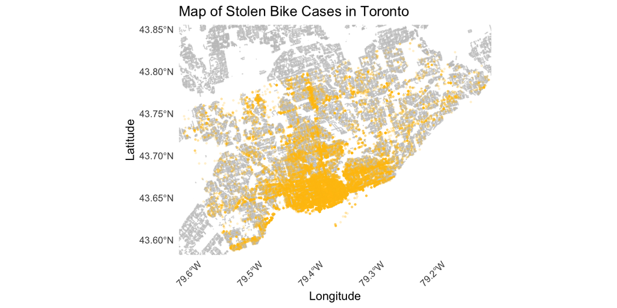

This map reveals a high concentration of bike theft incidents in downtown Toronto.

The map below takes a broader look, comparing bike theft incidents across different areas in Toronto. Each circle represents the number of theft cases in a region, with larger and brighter circles indicating higher numbers. At the center of the city, a massive **yellow** circle dominates the map, marking downtown Toronto as the hotspot for bike thefts. It’s clear that the dense urban core, with its high bike usage and heavy foot traffic, is where bikes like me are most at risk.

As we move away from the city center, the circles shrink and darken, representing areas with fewer reported thefts. These quieter neighborhoods show the clear contrast between high-risk zones and safer regions, highlighting how geography plays a role in bike security. Maps like this aren’t just data—they’re lifelines for bikes like me and our riders, offering a guide to navigating Toronto’s streets with caution and awareness of where the greatest risks lie.

[interactive chart not shown]

Note: The size of each point is proportional to the number of cases reported in each area, highlighting hotspots like downtown and other major regions. By clicking on each point, number of totals cases will be shown for different areas, including Downtown, Etobicoke, York, East York, North York, and Scarborough.

Putting it All Together

As this article comes to a close, let me reflect on what we’ve uncovered about life as a bike in Toronto. First, we looked at when I’m most at risk. It’s clear that thefts spike in the summer months from **May** to **August**, with a noticeable jump on **Fridays**. These patterns gave us an idea of the timing of bike thefts and helped us understand when extra caution is needed. Next, we dove into recovery rates—or rather, the lack of them. The huge gap between the number of stolen bikes and those recovered highlights just how hard it is for bikes like me to make it back to our owners. It’s a reminder of the need for better tracking and recovery systems.

We then explored where bike thefts happen, pinpointing hotspots like downtown Toronto and busy transit hubs where the risk is highest. The maps painted a clear picture of these danger zones, giving both cyclists and city planners a guide to where extra security measures are most urgently needed.

Altogether, these visualizations offer a complete story of Toronto’s bike theft problem. They show the when, where, and why of theft, giving insights that can inspire action. However, there’s still room to improve how we handle this data to make the insights even clearer and more actionable. For example, instead of ignoring incomplete entries, filling in missing details in ways that preserve key trends could offer a more complete picture. Additionally, breaking down regions into smaller, more specific areas could highlight particular streets or blocks where thefts are most frequent. This would allow for more focused responses and targeted solutions, ultimately making the findings more reliable and impactful.

Moving forward, Toronto can do more to protect bikes like me by creating more secure parking, working closely with registration platforms like Project 529, and expanding targeted programs like Project Sentry in high-theft areas. Maybe future studies will take this analysis nationwide, shedding light on bike theft patterns across Canada. With all these efforts combined, cyclists, city officials, and advocacy groups can work together to make Toronto a **safer** place for bikes like me to ride, rest, and thrive.

Conclusion

**This article is a reminder**: as more people turn to biking in Toronto, the risk of **theft** continues to grow. For bikes like me, the world is full of possibilities—but also risks. Whether you’re a daily commuter or a weekend adventurer, taking extra steps to protect me can go a long way. A sturdy lock isn’t just a piece of metal; it’s a lifeline. Parking in well-lit, high-traffic areas makes thieves think twice. And registering me with platforms like Project 529 ensures I have a better chance of finding my way back home if the worst happens.

But beyond individual actions, we need a community effort. Cyclists, advocacy groups, and city planners must come together to create a **safer** Toronto. More secure bike parking, stronger recovery programs, and greater public awareness are the tools we need to keep rolling with confidence. For bikes like me, it’s not just about avoiding theft; it’s about helping Toronto’s cycling community thrive—through every season, every neighborhood, and every ride.

So as you unlock me and hop on for your next journey, remember this: every precaution you take protects not just me, but the joy of cycling itself. Together, let’s keep Toronto’s streets vibrant, its riders safe, and its bikes where they belong—under the sun, on the move, and by your side!

### References

- Bike Month. (2024). *Bike Month Toronto.* https://www.bikemonth.ca/toronto
- City of Toronto. (2019). *2019 cycling public opinion survey.* https://www.toronto.ca/wp-content/uploads/2021/04/8f76-2019-Cycling-Public-Option-Survey-City-of-Toronto-Cycling.pdf
- City of Toronto. (2024). *Bicycle parking.* https://www.toronto.ca/services-payments/streets-parking-transportation/cycling-in-toronto/bicycle-parking/
- CTV News. (2024). Should Toronto tear up its bike lanes to improve traffic flow? Critics say it’s not so simple. *CTV News.* https://www.ctvnews.ca/canada/should-toronto-tear-up-its-bike-lanes-to-improve-traffic-flow-critics-say-it-s-not-so-simple-1.7103768
- Cycle Toronto. (2021). Council talking about ending bike theft week. *Cycle Toronto.* https://www.cycleto.ca/council-talking-about-ending-bike-theft-week
- Project 529. (2024). *529 garage: Bike registration to reduce theft and help recovery.* https://project529.com/garage
- Shapiro, A. (2021). Bike thieves are on a roll during the pandemic. Here’s how to protect your ride. *NPR.* https://www.npr.org/2021/04/02/980008727/bike-thieves-are-on-a-roll-during-the-pandemic-heres-how-to-protect-your-ride
- Toronto Police Service. (2024a). *Bicycle registration.* https://www.tps.ca/services/bicycle-registration/
- Toronto Police Service. (2024b). *Bicycle safety & theft prevention.* https://www.tps.ca/crime-prevention/bicycle-safety-and-theft-prevention/
- Toronto Police Service. (2024c). *Bicycle thefts open data.* https://data.torontopolice.on.ca/datasets/TorontoPS::bicycle-thefts-open-data/about
- Toronto Police Service. (2024d). Project Sentry: Keeping Toronto safe. *Toronto Police Service.* https://www.tps.ca/media-centre/news-releases/fix-title-project-sentry/